# Análise de dados: Bimanual

Iara Souza e Clovis F Reis

2022-08-12

# Descrição da análise

O estudo toma como dados a leitura de uma plataforma de força sobre a qual o paciente levanta-se . Foram coletados dados de um grupo que sofreu a Intervenção e outro de Controle, em dois momentos distintos: Pré-Intervenção (M1) e Pós-Intervenção (M2).

Foram disponibilizados os arquivos de dados dos seguintes pacientes, com resultados em triplicata:

```r
# Obter Meta dados dos arquivos Bimanual ------------------------------------------------
meta <- get_metaData('04Bimanual')
tmp <- unique(meta[c('id','grupo','ind')])
print(tmp[order(tmp$grupo,tmp$ind),])
```

```
       id       grupo                                  ind
131  Ind4    Controle             Antonio Roberto de Lucca
143  Ind6    Controle                   Benta Lins Andrade
161  Ind9    Controle                         Delci Amélia
32  Ind16    Controle Maria Jose Pereira Oliveira Ferreira
44  Ind18    Controle       Maria Lucia Constantino Pineli
53  Ind20    Controle               Miguel Gregorio Covacs
62  Ind23    Controle           Nailza Isabel de Brito Paz
74  Ind25    Controle                         Nelson Lopes
89  Ind28    Controle                     Paschoal Geraldo
95  Ind29    Controle                   Primiano Francisco
107 Ind30    Controle                       Regina Rosolin
119 Ind32    Controle             Vicente de Paula Martins
125 Ind33    Controle                     Wolfgang Rodolfo
1    Ind1 Intervenção                      Adelaide Hirano
```

[output cut: 16 more lines]

# Obtenção dos dados

```r
map_df(1:nrow(meta), ~ {
  df_f <- getData(
    file_name = meta$path[.x],
    moment = meta$momento[.x],
    id = meta$id[.x],
    trat = meta$trat[.x],
    rep = meta$rep[.x],
    grupo = meta$grupo[.x],
    probs     = c(0.1, 0.9)
  )
}) -> df_f
```

# Calculo das métricas

Calculou-se os dados das métricas em função do tempo para cada paciente de ambos os momentos (M1 e M2).

Também foi calculado o tempo médio de todas as leituras efetuadas. Foram considerados picos máximos de T2 somente valores abaixo deste valor médio. Isso foi necessário, porque algumas amostras apresentaram valores de leitura finais superiores ao pico T2.

```r
#acha o tempo médio dos gráficos.
tmp<- df_f[,c('tempo','id','fz')]%>%
  group_by(id) %>%
  summarise(tempo = mean(tempo), sd(tempo))
meanTime <- mean(tmp$tempo) + sd(tmp$tempo)
```

# Separação em sub-grupos

Os dados foram separados em 4 subgrupos, de acordo com o tratamento recebido (Controle e Intervenção) e momento de tomada de dados (M1 e M2).

Durante o processo, também foi realizada a média das 3 replicatas do experimento, agrupados por paciente (Ind) e pelo tempo.

```r
#cria subgrupos
tmp <- get_subgrupos(df_f)
ctlM1 <- tmp[[1]]
ctlM2 <- tmp[[2]]
itvM1 <- tmp[[3]]
itvM2 <- tmp[[4]]
```

Pacientes cujos arquivos de amostras não se encontravam presentes nos dois tempos foram excluídos da análise.

Os dados foram tratados de forma que as linhas resultantes aparecessem suavizadas.

```r
# Indivíduos que não possuem amostras nos dois momentos
cat('Ctl em M1 mas não em M2:\n', unique(ctlM1$id[!ctlM1$id %in% unique(ctlM2$id)]),
    '\nCtl em M2 mas não em M1:\n',unique(ctlM2$id[!ctlM2$id %in% unique(ctlM1$id)]),
    '\nItv em M1 mas não em M2:\n',unique(itvM1$id[!itvM1$id %in% unique(itvM2$id)]),
    '\nItv em M2 mas não em M1:\n',unique(itvM2$id[!itvM2$id %in% unique(itvM1$id)]))
```

```
Ctl em M1 mas não em M2:
 Ind20
Ctl em M2 mas não em M1:

Itv em M1 mas não em M2:
 Ind11 Ind19 Ind26
Itv em M2 mas não em M1:
```

```r
# Remove indivíduos que não possuem amostras nos dois momentos
ctlM1 <- ctlM1[ctlM1$id %in% unique(ctlM1$id[ctlM1$id %in% unique(ctlM2$id)]),]
ctlM2 <- ctlM2[ctlM2$id %in% unique(ctlM2$id[ctlM2$id %in% unique(ctlM1$id)]),]
itvM1 <- itvM1[itvM1$id %in% unique(itvM1$id[itvM1$id %in% unique(itvM2$id)]),]
itvM2 <- itvM2[itvM2$id %in% unique(itvM2$id[itvM2$id %in% unique(itvM1$id)]),]

spar = 0.01
#suaviza as linhas
ctlM1$fzS<-smooth.spline(ctlM1$fz, spar = spar, df = 5)$y
ctlM2$fzS<-smooth.spline(ctlM2$fz, spar = spar, df = 5)$y
itvM1$fzS<-smooth.spline(itvM1$fz, spar = spar, df = 5)$y
itvM2$fzS<-smooth.spline(itvM2$fz, spar = spar, df = 5)$y

#cria coluna para normalização do sinal
ctlM1$fzN<-0
ctlM2$fzN<-0
itvM1$fzN<-0
itvM2$fzN<-0
```

# Encontrar o T2 do gráfico dos pacientes

O momento em que o paciente levanta-se do assento é caracterizado por um pico no gráfico de força. Aqui foi realizada a detecção deste pico.

Também foram estimados os fatores de correção dos valores de força zero, assim como foi calculado o valor base para translação dos gráficos sobre o eixo do tempo, de forma que todos os picos T2 pudessem ser plotados com um mesmo valor para o eixo X.

```r
picos <- get_picos(ctlM1, ctlM2, itvM1, itvM2)
# ajuste do eixo X
corrX <- 0
  #floor(mean(picos$T1[!is.na(picos$T1)]) + 2*sd(picos$T1[!is.na(picos$T1)]))
cat('Correção do eixo dos X:\n Os T2 de todos pacientes serão alinhados no tempo', corrX,'s.')
```

```
Correção do eixo dos X:
 Os T2 de todos pacientes serão alinhados no tempo 0 s.
```

Realizou-se a translação de cada gráfico de forma a posicionar os valores de força zero na ordenada correta.

Também foram calculados valores normalizados entre -1 e 1 para os gráficos individuais do grupo Intervenção.

Ao final do processo de detecção das fases do Bimanual, notou-se que, devido a heterogeinidade de formas do sinal, a rotina de deteção automática dos tempos limites não obteve sucesso em alguns casos, em especial para T4. Para solucionar o problema, realizou-se uma curadoria manual dos casos de falha.

Tempos antes da curadoria:

```r
print(picos)
```

```
      df    id tempo     corrY    T1    T2    T3    T4 max min
1  ctlM1 Ind16 3.509  78.96040 0.200 3.510 4.844 6.205   0   0
2  ctlM1 Ind18 3.944 283.17798 1.206 3.945 5.219    NA   0   0
3  ctlM1 Ind23 5.575 354.90684 3.811 5.576    NA    NA   0   0
4  ctlM1 Ind25 4.746 407.56829 3.504 4.747    NA    NA   0   0
5  ctlM1 Ind28 5.516 364.90540 1.477 3.888 5.517    NA   0   0
6  ctlM1 Ind29 4.427 372.25633 1.188 3.182 4.428 5.676   0   0
7  ctlM1 Ind30 5.593 357.52965 3.797 5.594    NA    NA   0   0
8  ctlM1 Ind32 4.298 378.84573 4.299 5.662    NA    NA   0   0
9  ctlM1 Ind33 5.999 479.94495 4.666 6.000    NA    NA   0   0
10 ctlM1  Ind4 4.731 551.47876 4.732 6.202    NA    NA   0   0
11 ctlM1  Ind6 3.976 366.65577 2.856 3.977 5.338    NA   0   0
12 ctlM1  Ind9 5.935 326.24191 4.612 5.936    NA    NA   0   0
13 ctlM2 Ind16 4.668  96.20484 0.172 3.536 4.669 5.861   0   0
14 ctlM2 Ind18 4.551 295.59750 3.301 4.552 5.787    NA   0   0
```

[output cut: 38 more lines]

```r
#intervenção manual no ajuste dos Ts
#write_csv(picos,'../data/picosB.csv')
tmp <- ajusta_XY(picos,
          picosFile = '../data/picosB.csv',
          ctlM1, ctlM2, itvM1, itvM2)
picos <- tmp[[1]]
ctlM1 <- tmp[[2]]
ctlM2 <- tmp[[3]]
itvM1 <- tmp[[4]]
itvM2 <- tmp[[5]]
```

Tempos após a curadoria:

```r
print(picos)
```

```
      df    id tempo     corrY    T1    T2    T3     T4        min       max
1  ctlM1 Ind16 3.509  78.96040 1.250 3.510 4.844  6.205  -29.28334 417.84609
2  ctlM1 Ind18 3.944 283.17798 1.206 3.945 5.219  7.600 -253.29815 299.70852
3  ctlM1 Ind23 5.575 354.90684 1.100 5.576 7.950 10.500 -302.42331 356.93386
4  ctlM1 Ind25 4.746 407.56829 1.580 3.504 4.747  7.300 -402.56211 288.16621
5  ctlM1 Ind28 5.516 364.90540 1.477 3.888 5.517  7.900 -236.72708 389.37435
6  ctlM1 Ind29 4.427 372.25633 1.188 3.182 4.428  5.676 -310.19784 415.40893
7  ctlM1 Ind30 5.593 357.52965 0.000 5.594 7.150  9.300 -288.91961 432.73664
8  ctlM1 Ind32 4.298 378.84573 0.000 4.299 5.662  7.600 -273.29722 412.11270
9  ctlM1 Ind33 5.999 479.94495 1.400 4.666 6.000  7.700 -407.38960 493.25804
10 ctlM1  Ind4 4.731 551.47876 1.350 4.732 6.202  7.300 -567.51999 197.01142
11 ctlM1  Ind6 3.976 366.65577 1.050 2.856 3.977  5.338 -355.69968 148.62277
12 ctlM1  Ind9 5.935 326.24191 1.150 4.612 5.936  8.500 -251.51305 235.14469
13 ctlM2 Ind16 4.668  96.20484 1.300 3.536 4.669  5.861  -44.83561 419.42745
14 ctlM2 Ind18 4.551 295.59750 3.301 4.552 5.787  6.900 -306.59266 303.39721
```

[output cut: 38 more lines]

# Visualização dos dados

## Normalização

Como as amplitudes obtidas pela plataforma são dependentes do peso do paciente e da força por ele aplicada para levantar-se, optou-se por realizar uma normalização nos valores de intensidade de sinal obtido, a fim de facilitar a comparação visual dos resultados dos diversos pacientes.

Assim, os valores daquelas linhas foram normalizados entre -1 e 1, mantendo-se a linha base do zero. Este procedimento possui o inconveniente de distorcer valores negativos, já que eles normalmente são de intensidade menor que os positivos. Isso, porém, não afetará a precisão da visualização, já que todos os dados serão normalizados da mesma forma.

O valor inicial da aferição de sinal para cada paciente foi corrigido tomando-se a média da intencidade das 100 primeiras amostras, subtraindo-se esse valor de todo o conjunto.

## Sumário

Transformando os dados fornecidos em gráficos, obtemos para o grupo controle:

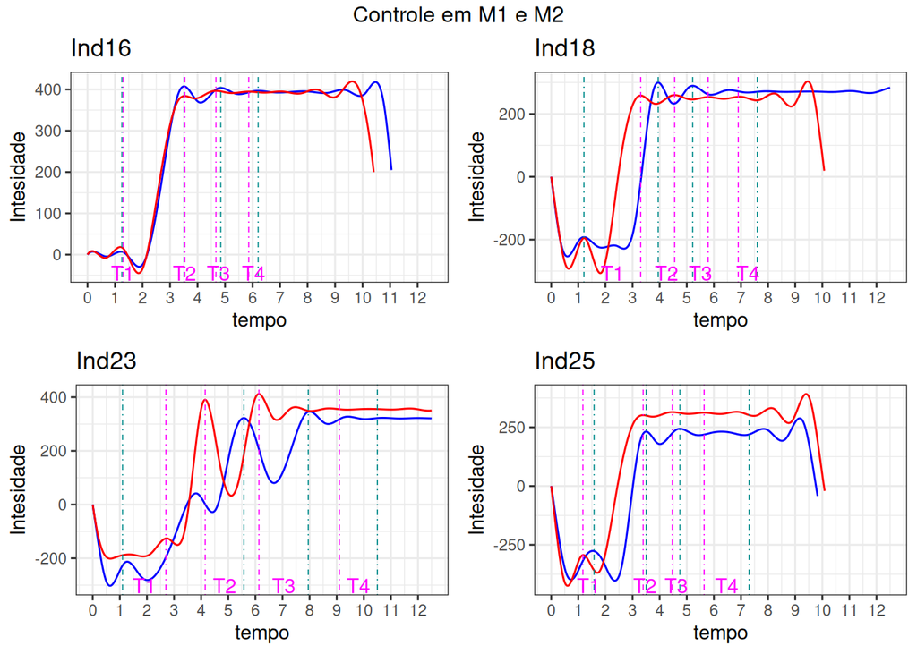

Dados do grupo de controle em M1 e M2. A linha azul indica o tempo M1 e a vermelha M2. As linhas verticais ciano e magenta identificam os pontos T1, T2, T3 e T4 dos tempos M1 e M2, respectivamente.

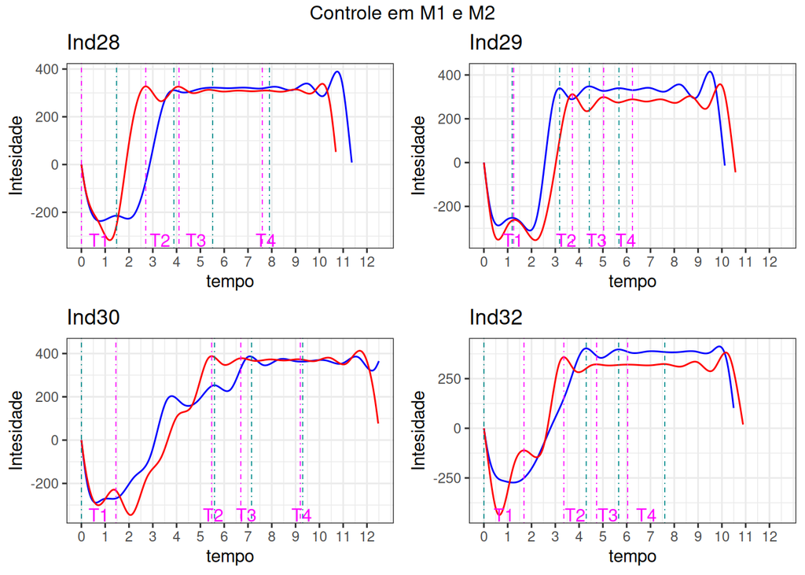

Dados do grupo de controle em M1 e M2. A linha azul indica o tempo M1 e a vermelha M2. As linhas verticais ciano e magenta identificam os pontos T1, T2, T3 e T4 dos tempos M1 e M2, respectivamente.

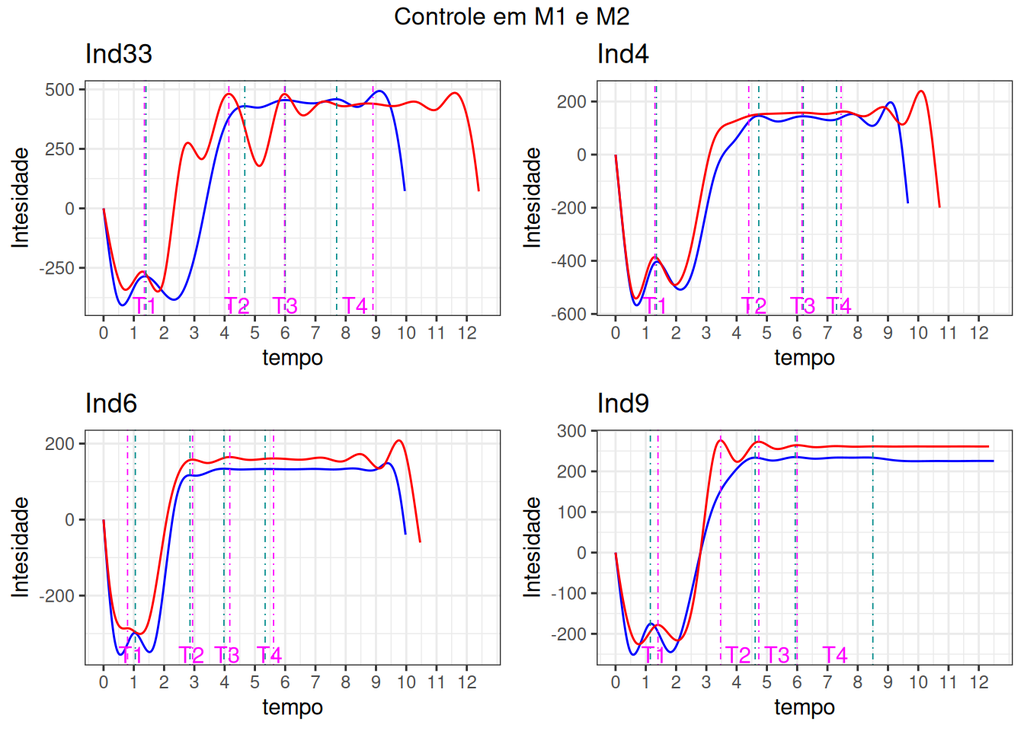

Dados do grupo de controle em M1 e M2. A linha azul indica o tempo M1 e a vermelha M2. As linhas verticais ciano e magenta identificam os pontos T1, T2, T3 e T4 dos tempos M1 e M2, respectivamente.

```r
#imprime gráficos controle antes e depois
ind = 'Ind30'
gCtl <- list()
idxC = 0
for(ind in unique(ctlM1$id)){
  idxC = idxC+1
  T11 <- picos$T1[picos$id == ind &
                   picos$df == 'ctlM1']
  T21 <- picos$T2[picos$id == ind &
                   picos$df == 'ctlM1']
  T31 <- picos$T3[picos$id == ind &
                   picos$df == 'ctlM1']
  T41 <- picos$T4[picos$id == ind &
                   picos$df == 'ctlM1']
  T12 <- picos$T1[picos$id == ind &
                   picos$df == 'ctlM2']
  T22 <- picos$T2[picos$id == ind &
                   picos$df == 'ctlM2']
  T32 <- picos$T3[picos$id == ind &
                   picos$df == 'ctlM2']
  T42 <- picos$T4[picos$id == ind &
                   picos$df == 'ctlM2']
  min <- min(picos$min[picos$id == ind &
                   picos$df == 'ctlM1'],
             picos$min[picos$id == ind &
                         picos$df == 'ctlM2'])
  gCtl[[idxC]] <-
    ggplot()+
    # xlim(0,12.5)+
    ylab("Intesidade")+
    ggtitle(ind)+
    geom_line(data = ctlM1[ctlM1$id == ind,],
              aes(x=tempo, y= fzS),
              color='blue')+
    geom_line(data = ctlM2[ctlM2$id == ind,],
              aes(x=tempo, y= fzS),
              color='red')+
  geom_vline(xintercept = T11, color='cyan4', linetype = "dotdash", size= 0.3)+
  geom_vline(xintercept = T21, color='cyan4', linetype = "dotdash", size= 0.3)+
  geom_vline(xintercept = T31, color='cyan4', linetype = "dotdash", size= 0.3)+
  geom_vline(xintercept = T41, color='cyan4', linetype = "dotdash", size= 0.3)+
  geom_vline(xintercept = T12, color='magenta', linetype = "dotdash", size= 0.3)+
  geom_vline(xintercept = T22, color='magenta', linetype = "dotdash", size= 0.3)+
  geom_vline(xintercept = T32, color='magenta', linetype = "dotdash", size= 0.3)+
  geom_vline(xintercept = T42, color='magenta', linetype = "dotdash", size= 0.3)+
  annotate('text',label = c('T1','T2','T3','T4'),
           x=c((T11+T12)/2,(T21+T22)/2,(T31+T32)/2,(T41+T42)/2),
           y=c(rep(min,4)),
           color='magenta')+
    scale_x_continuous(breaks = seq(0, 12, by = 1),
                       limits = c(0,12.5))

}
idx=1
while(idx <= length(gCtl)){
  ini = idx
  if(idx+3 > length(gCtl)){
    fim = length(gCtl)
  }else{
    fim = idx+3
  }
  grid.arrange(grobs = gCtl[ini:fim], ncol=2,top="Controle em M1 e M2")
  idx = idx+4
}
```

E os seguintes gráficos para o grupo intervenção:

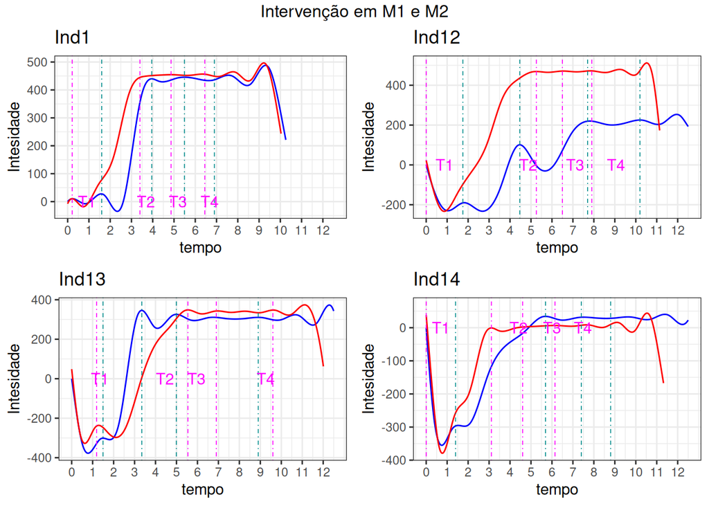

Dados do grupo de intervenção em M1 e M2. A linha azul indica o tempo M1 e a vermelha M2. As linhas verticais ciano e magenta identificam os pontos T1, T2, T3 e T4 dos tempos M1 e M2, respectivamente.

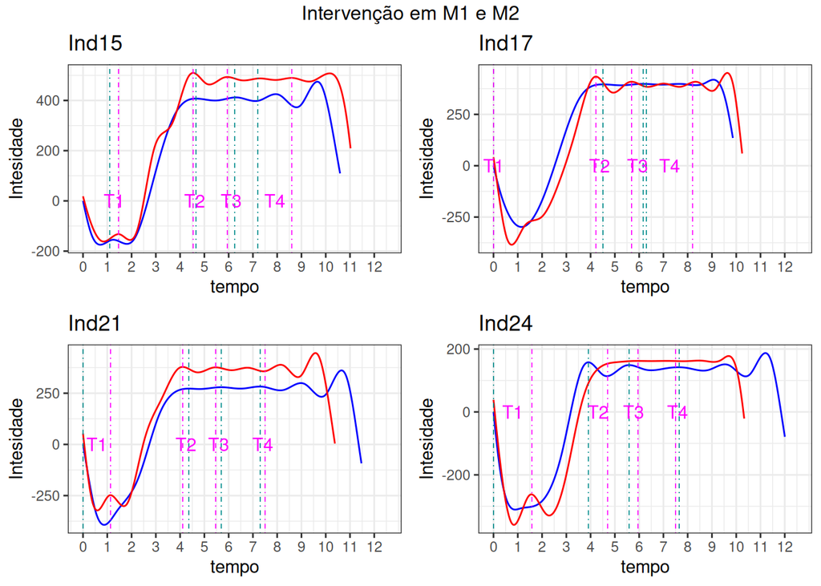

Dados do grupo de intervenção em M1 e M2. A linha azul indica o tempo M1 e a vermelha M2. As linhas verticais ciano e magenta identificam os pontos T1, T2, T3 e T4 dos tempos M1 e M2, respectivamente.

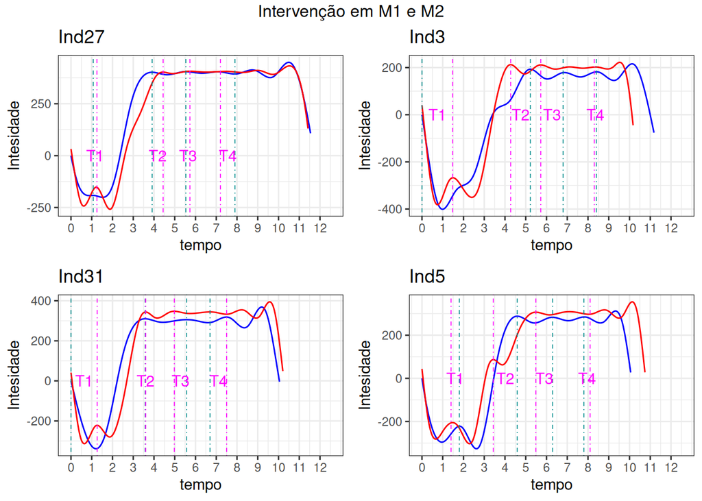

Dados do grupo de intervenção em M1 e M2. A linha azul indica o tempo M1 e a vermelha M2. As linhas verticais ciano e magenta identificam os pontos T1, T2, T3 e T4 dos tempos M1 e M2, respectivamente.

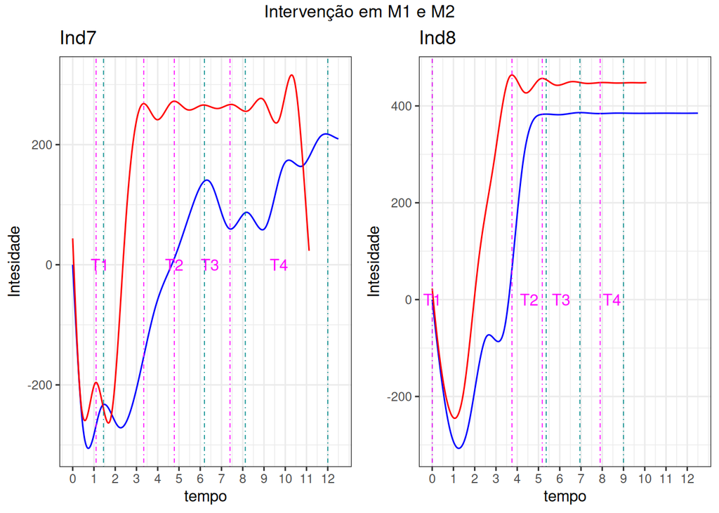

Dados do grupo de intervenção em M1 e M2. A linha azul indica o tempo M1 e a vermelha M2. As linhas verticais ciano e magenta identificam os pontos T1, T2, T3 e T4 dos tempos M1 e M2, respectivamente.

```r
picos <- read_csv('../data/picosB.csv')

#imprime gráficos intervenção antes e depois
gItv <- list()
idxI = 0
for(ind in unique(itvM1$id)){
  T11 <- picos$T1[picos$id == ind &
                   picos$df == 'itvM1']
  T21 <- picos$T2[picos$id == ind &
                   picos$df == 'itvM1']
  T31 <- picos$T3[picos$id == ind &
                   picos$df == 'itvM1']
  T41 <- picos$T4[picos$id == ind &
                   picos$df == 'itvM1']
  T12 <- picos$T1[picos$id == ind &
                   picos$df == 'itvM2']
  T22 <- picos$T2[picos$id == ind &
                   picos$df == 'itvM2']
  T32 <- picos$T3[picos$id == ind &
                   picos$df == 'itvM2']
  T42 <- picos$T4[picos$id == ind &
                   picos$df == 'itvM2']
  min <- min(picos$min[picos$id == ind &
                   picos$df == 'itvM1'],
             picos$min[picos$id == ind &
                         picos$df == 'itvM2'])

  idxI = idxI+1
  gItv[[idxI]] <-
    ggplot()+
    # xlim(0,12.5)+
    ylab("Intesidade")+
    ggtitle(ind)+
    geom_line(data = itvM1[itvM1$id == ind,],
              aes(x=tempo, y= fzS),
              color='blue')+
    geom_line(data = itvM2[itvM2$id == ind,],
              aes(x=tempo, y= fzS),
              color='red')+
  geom_vline(xintercept = T11, color='cyan4', linetype = "dotdash", size= 0.3)+
  geom_vline(xintercept = T21, color='cyan4', linetype = "dotdash", size= 0.3)+
  geom_vline(xintercept = T31, color='cyan4', linetype = "dotdash", size= 0.3)+
  geom_vline(xintercept = T41, color='cyan4', linetype = "dotdash", size= 0.3)+
  geom_vline(xintercept = T12, color='magenta', linetype = "dotdash", size= 0.3)+
  geom_vline(xintercept = T22, color='magenta', linetype = "dotdash", size= 0.3)+
  geom_vline(xintercept = T32, color='magenta', linetype = "dotdash", size= 0.3)+
  geom_vline(xintercept = T42, color='magenta', linetype = "dotdash", size= 0.3)+
  annotate('text',label = c('T1','T2','T3','T4'),
           x=c((T11+T12)/2,(T21+T22)/2,(T31+T32)/2,(T41+T42)/2),
           y=c(rep(min,4)),
           color='magenta')+
    scale_x_continuous(breaks = seq(0, 12, by = 1),
                       limits = c(0,12.5))

}
idx=1
while(idx <= length(gItv)){
  ini = idx
  if(idx+3 > length(gItv)){
    fim = length(gItv)
  }else{
    fim = idx+3
  }
  grid.arrange(grobs = gItv[ini:fim], ncol=2,top="Intervenção em M1 e M2")
  idx = idx+4
}
```

## Linha de referência para controle

Calculou-se a média e o desvio do sinal padrão para cada unidade de tempo, independentemente de paciente ou replicata.

A seguir, removeu-se todos os instantes de tempo onde existiam menos que 10 amostras, a fim de dar maior precisão e significância à linha base.

Obteve-se assim 3 linhas base:

- Linha da média de valores a cada instante de tempo;
- Linha indicadora de média mais um desvio padrão; e
- Linha indicadora de média menos um desvio padrão.

Assim obteve-se o seguinte gráfico base para referência:

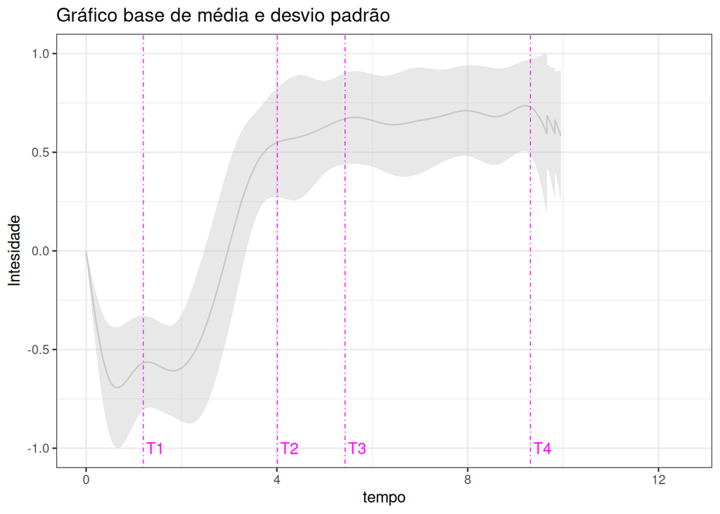

```r
#cria linha de referencia do controle.
#usa todas as amostras de controle de M1 e M2

#unindo os controles
#ctl <- rbind(ctlM1,ctlM2)
ctl <- ctlM1
# Arredonda tempo para 3 digitos
ctl$tempo <- round(ctl$tempo, digits = 3)
ctl <- ctl %>%
  group_by(tempo) %>%
  summarise(fzM = mean(fzS),
            sd(fzS),
            fzUp = mean(fzS) + sd(fzS),
            fzDw = mean(fzS) - sd(fzS),
            n = n())
ctl$fzMN <-0
ctl$fzUpN <-0
ctl$fzDwN <-0

#somente tempos que constam em mais de 10 amostras
ctl<-ctl[ctl$n >= 10,]
#normaliza entre 0 e 1
min<-min(ctl$fzDw)
max<-max(ctl$fzUp)
ctl$fzMN[ctl$fzM>=0]<- ctl$fzM[ctl$fzM>=0]/max
ctl$fzMN[ctl$fzM<0]<- -ctl$fzM[ctl$fzM<0]/min
ctl$fzUpN[ctl$fzUp>=0]<- ctl$fzUp[ctl$fzUp>=0]/max
ctl$fzUpN[ctl$fzUp<0]<- -ctl$fzUp[ctl$fzUp<0]/min
ctl$fzDwN[ctl$fzDw>=0]<- ctl$fzDw[ctl$fzDw>=0]/max
ctl$fzDwN[ctl$fzDw<0]<- -ctl$fzDw[ctl$fzDw<0]/min

#calcula os Ts para o controle
T1 <- mean(picos$T1[!is.na(picos$T1) &
                      (picos$df == 'ctlM1' |
                         picos$df == 'ctlM2')])
T2 <- mean(picos$T2[!is.na(picos$T2) &
                      (picos$df == 'ctlM1' |
                         picos$df == 'ctlM2')])
T3 <- mean(picos$T3[!is.na(picos$T3) &
                      (picos$df == 'ctlM1' |
                         picos$df == 'ctlM2')])
T4 <- mean(picos$T4[!is.na(picos$T4) &
                      (picos$df == 'ctlM1' |
                         picos$df == 'ctlM2')])

T1 <- 1.2
T4 <- 9.315

ggplot()+
  xlim(0,12.5)+
  ylab("Intesidade")+
  ggtitle('Gráfico base de média e desvio padrão')+
  geom_ribbon(data = ctl,
              aes(x=tempo,ymax=fzUpN,ymin=fzDwN ),
              fill = alpha('grey',alpha = 0.35))+
  geom_line(data = ctl,
            aes(x=tempo,y=fzMN),
            color = alpha('grey',alpha = 0.75))+
  geom_vline(xintercept = T1, color='magenta', linetype = "dotdash", size= 0.3)+
  geom_vline(xintercept = T2, color='magenta', linetype = "dotdash", size= 0.3)+
  geom_vline(xintercept = T3, color='magenta', linetype = "dotdash", size= 0.3)+
  geom_vline(xintercept = T4, color='magenta', linetype = "dotdash", size= 0.3)+
  annotate('text',label = c('T1','T2','T3','T4'),
           x=c(T1+0.25,T2+0.25,T3+0.25,T4+0.25),
           y=c(-1,-1,-1,-1),
           color='magenta')
```

Os pontos T1, T2, T3 e T4 foram obtidos com base na variação do sinal do controle e foram utilizados como referência para todas as análises subsequentes

Observe que os dados com valores negativos não aparecem com sua amplitude em verdadeira grandeza.

# Resultados

O procedimento descrito acima também foi realizado com o grupo intervenção em M1.

Quando confrontado com os dados de controle, obteve-se:

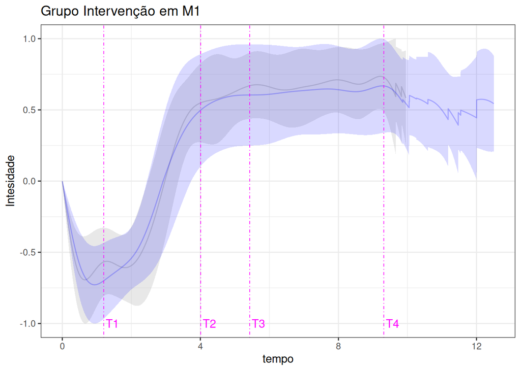

```r
itv <- itvM1
# Arredonda tempo para 3 digitos
itv$tempo <- round(itv$tempo, digits = 3)
itv <- itv %>%
  group_by(tempo) %>%
  summarise(fzM = mean(fzS),
            sd(fzS),
            fzUp = mean(fzS) + 1*sd(fzS),
            fzDw = mean(fzS) - 1*sd(fzS),
            n = n())
itv$fzMN <-0
itv$fzUpN <-0
itv$fzDwN <-0
#somente tempos que constam em mais de 5 amostras
itv<-itv[itv$n >= 5,]
#normaliza entre 0 e 1
min<-min(itv$fzDw)
max<-max(itv$fzUp)
itv$fzMN[itv$fzM>=0]<- itv$fzM[itv$fzM>=0]/max
itv$fzMN[itv$fzM<0]<- -itv$fzM[itv$fzM<0]/min
itv$fzUpN[itv$fzUp>=0]<- itv$fzUp[itv$fzUp>=0]/max
itv$fzUpN[itv$fzUp<0]<- -itv$fzUp[itv$fzUp<0]/min
itv$fzDwN[itv$fzDw>=0]<- itv$fzDw[itv$fzDw>=0]/max
itv$fzDwN[itv$fzDw<0]<- -itv$fzDw[itv$fzDw<0]/min

itv1 <- itv

ggplot()+
  xlim(0,12.5)+
  ylab("Intesidade")+
  ggtitle('Grupo Intervenção em M1')+
  geom_ribbon(data = ctl,
              aes(x=tempo,ymax=fzUpN,ymin=fzDwN ),
              fill = alpha('grey',alpha = 0.35))+
  geom_line(data = ctl,
            aes(x=tempo,y=fzMN),
            color = alpha('grey',alpha = 0.75))+
  geom_ribbon(data = itv1,
              aes(x=tempo,ymax=fzUpN,ymin=fzDwN ),
              fill = alpha('blue',alpha = 0.15))+
  geom_line(data = itv1,
            aes(x=tempo,y=fzMN),
            color = alpha('blue',alpha = 0.25))+
  geom_vline(xintercept = T1, color='magenta', linetype = "dotdash", size= 0.3)+
  geom_vline(xintercept = T2, color='magenta', linetype = "dotdash", size= 0.3)+
  geom_vline(xintercept = T3, color='magenta', linetype = "dotdash", size= 0.3)+
  geom_vline(xintercept = T4, color='magenta', linetype = "dotdash", size= 0.3)+
  annotate('text',label = c('T1','T2','T3','T4'),
           x=c(T1+0.25,T2+0.25,T3+0.25,T4+0.25),
           y=c(-1,-1,-1,-1),
           color='magenta')
```

De forma semelhante, o procedimento foi realizado com o grupo intervenção em M2, sendo obtido o seguinte gráfico :

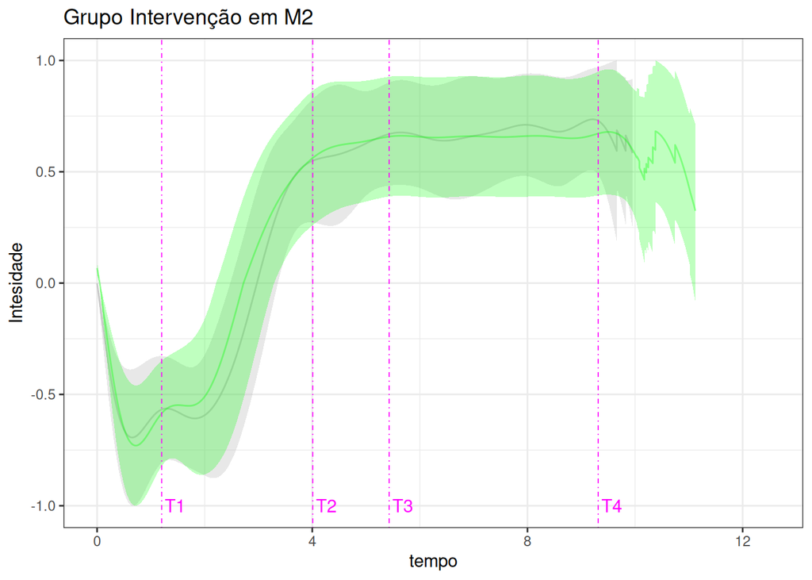

Comparação entre os dados do grupo de controle em e o grupo intervenção em M2. A linha cinza indica a posição da média em cada instante e a área cinza o desvio padrão do controle.A linha verde indica a posição da média em cada instante e a área verde o desvio padrão do grupo intervenção em M2.

```r
itv <- itvM2
# Arredonda tempo para 3 digitos
itv$tempo <- round(itv$tempo, digits = 3)
itv <- itv %>%
  group_by(tempo) %>%
  summarise(fzM = mean(fzS),
            sd(fzS),
            fzUp = mean(fzS) + 1*sd(fzS),
            fzDw = mean(fzS) - 1*sd(fzS),
            n = n())
itv$fzMN <-0
itv$fzUpN <-0
itv$fzDwN <-0

#somente tempos que constam em mais de 5 amostras
itv<-itv[itv$n >= 5,]
#normaliza entre 0 e 1
min<-min(itv$fzDw)
max<-max(itv$fzUp)
itv$fzMN[itv$fzM>=0]<- itv$fzM[itv$fzM>=0]/max
itv$fzMN[itv$fzM<0]<- -itv$fzM[itv$fzM<0]/min
itv$fzUpN[itv$fzUp>=0]<- itv$fzUp[itv$fzUp>=0]/max
itv$fzUpN[itv$fzUp<0]<- -itv$fzUp[itv$fzUp<0]/min
itv$fzDwN[itv$fzDw>=0]<- itv$fzDw[itv$fzDw>=0]/max
itv$fzDwN[itv$fzDw<0]<- -itv$fzDw[itv$fzDw<0]/min

itv2 <- itv

ggplot()+
  xlim(0,12.5)+
  ylab("Intesidade")+
  ggtitle('Grupo Intervenção em M2')+
  geom_ribbon(data = ctl,
              aes(x=tempo,ymax=fzUpN,ymin=fzDwN ),
              fill = alpha('grey',alpha = 0.35))+
  geom_line(data = ctl,
            aes(x=tempo,y=fzMN),
            color = alpha('grey',alpha = 0.75))+
  geom_ribbon(data = itv2,
              aes(x=tempo,ymax=fzUpN,ymin=fzDwN ),
              fill = alpha('green',alpha = 0.25))+
  geom_line(data = itv2,
            aes(x=tempo,y=fzMN),
            color = alpha('green',alpha = 0.35))+
  geom_vline(xintercept = T1, color='magenta', linetype = "dotdash", size= 0.3)+
  geom_vline(xintercept = T2, color='magenta', linetype = "dotdash", size= 0.3)+
  geom_vline(xintercept = T3, color='magenta', linetype = "dotdash", size= 0.3)+
  geom_vline(xintercept = T4, color='magenta', linetype = "dotdash", size= 0.3)+
  annotate('text',label = c('T1','T2','T3','T4'),
           x=c(T1+0.25,T2+0.25,T3+0.25,T4+0.25),
           y=c(-1,-1,-1,-1),
           color='magenta')
```

Comparando-se os gráficos de M1 e M2:

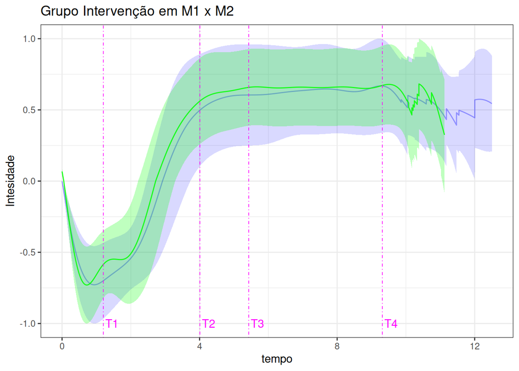

Comparação entre os dados do grupo intervenção em M1 e M2. A linha azul indica a posição da média em cada instante e a área azul o desvio padrão do grupo intervenção em M1. A linha verde indica a posição da média em cada instante e a área verde o desvio padrão do grupo intervenção em M2.

```r
ggplot()+
  xlim(0,12.5)+
  ylab("Intesidade")+
  ggtitle('Grupo Intervenção em M1 x M2')+
  geom_ribbon(data = itv1,
              aes(x=tempo,ymax=fzUpN,ymin=fzDwN ),
              fill = alpha('blue',alpha = 0.15))+
  geom_line(data = itv1,
            aes(x=tempo,y=fzMN),
            color = alpha('blue',alpha = 0.35))+
  geom_ribbon(data = itv2,
              aes(x=tempo,ymax=fzUpN,ymin=fzDwN ),
              fill = alpha('green',alpha = 0.25))+
  geom_line(data = itv2,
            aes(x=tempo,y=fzMN),
            color = alpha('green',alpha = 0.85))+
  geom_vline(xintercept = T1, color='magenta', linetype = "dotdash", size= 0.3)+
  geom_vline(xintercept = T2, color='magenta', linetype = "dotdash", size= 0.3)+
  geom_vline(xintercept = T3, color='magenta', linetype = "dotdash", size= 0.3)+
  geom_vline(xintercept = T4, color='magenta', linetype = "dotdash", size= 0.3)+
  annotate('text',label = c('T1','T2','T3','T4'),
           x=c(T1+0.25,T2+0.25,T3+0.25,T4+0.25),
           y=c(-1,-1,-1,-1),
           color='magenta')
```

Nota-se que, em ambos os casos, os valores de controle e de intervenção parecem ser semelhantes, assim como parece não haver diferença entre os resultados obtidos antes e depois da intervenção.

Analisando os gráficos de cada individuo:

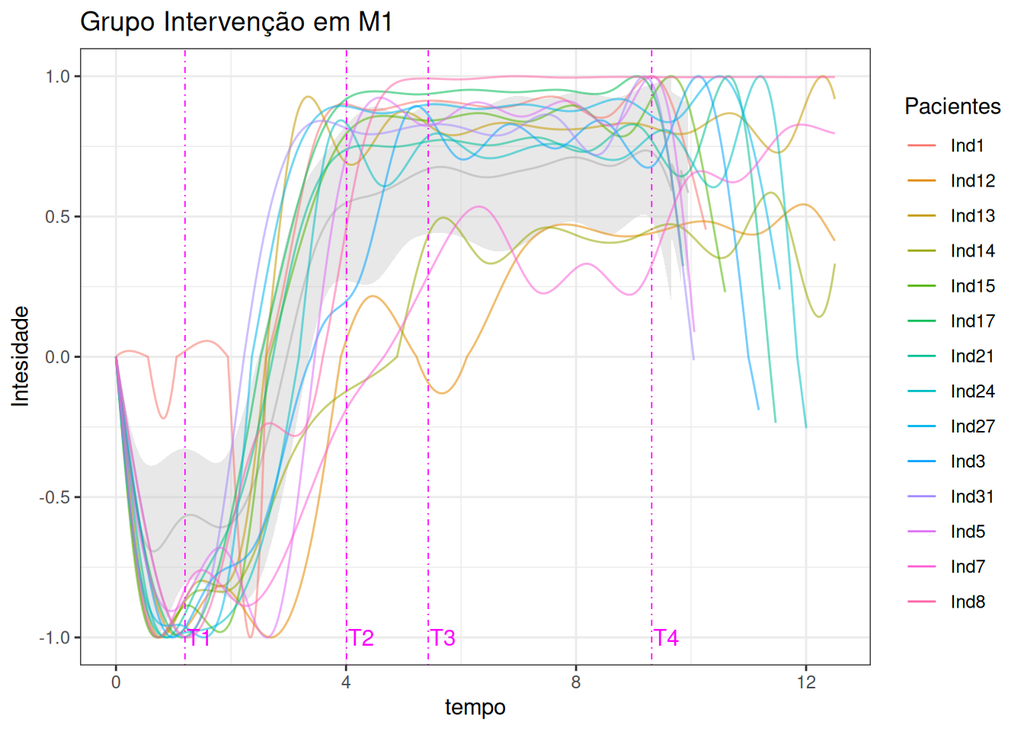

```r
ggplot()+
  xlim(0,12.5)+
  ylab("Intesidade")+
  ggtitle('Grupo Intervenção em M1')+
  geom_ribbon(data = ctl,
              aes(x=tempo,ymax=fzUpN,ymin=fzDwN ),
              fill = alpha('grey',alpha = 0.35))+
  geom_line(data = ctl,
            aes(x=tempo,y=fzMN),
            color = alpha('grey',alpha = 0.75))+
  geom_line(data = itvM1,
            aes(x=tempo, y= fzN, color = as.factor(id), alpha = 0.4))+
  guides(color=guide_legend(title="Pacientes"),
         alpha="none")+
  geom_vline(xintercept = T1, color='magenta', linetype = "dotdash", size= 0.3)+
  geom_vline(xintercept = T2, color='magenta', linetype = "dotdash", size= 0.3)+
  geom_vline(xintercept = T3, color='magenta', linetype = "dotdash", size= 0.3)+
  geom_vline(xintercept = T4, color='magenta', linetype = "dotdash", size= 0.3)+
  annotate('text',label = c('T1','T2','T3','T4'),
           x=c(T1+0.25,T2+0.25,T3+0.25,T4+0.25),
           y=c(-1,-1,-1,-1),
           color='magenta')
```

Nota-se que todos os gráficos possuem comportamento semelhante entre as linhas T1, T2 e T3. A maior variação ocorre durante a estabilização do paciente, entre T3 e T4. O mesmo acontece em M2.

É importante lembrar que as amplitudes, embora bastante heterogêneas, para esta análise possuem importância apenas para definir as diferentes fases do processo de levantar, já que estão intimamente ligadas ao peso do paciente.

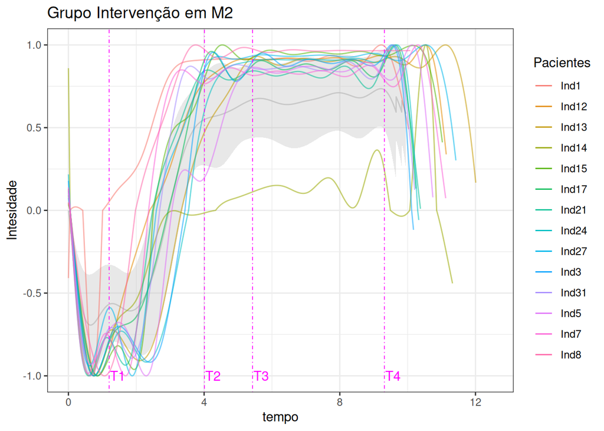

Comparação entre os dados do grupo de controle em e o grupo intervenção em M2. A linha cinza indica a posição da média em cada instante e a área cinza o desvio padrão do controle. As linhas coloridas indicam os valores normalizados de cada paciente do grupo intervenção em M2.

```r
ggplot()+
  xlim(0,12.5)+
  ylab("Intesidade")+
  ggtitle('Grupo Intervenção em M2')+
  geom_ribbon(data = ctl,
              aes(x=tempo,ymax=fzUpN,ymin=fzDwN ),
              fill = alpha('grey',alpha = 0.35))+
  geom_line(data = ctl,
            aes(x=tempo,y=fzMN),
            color = alpha('grey',alpha = 0.75))+
  geom_line(data = itvM2,
            aes(x=tempo, y= fzN, color = as.factor(id), alpha = 0.4))+
  guides(color=guide_legend(title="Pacientes"),
         alpha="none")+
  geom_vline(xintercept = T1, color='magenta', linetype = "dotdash", size= 0.3)+
  geom_vline(xintercept = T2, color='magenta', linetype = "dotdash", size= 0.3)+
  geom_vline(xintercept = T3, color='magenta', linetype = "dotdash", size= 0.3)+
  geom_vline(xintercept = T4, color='magenta', linetype = "dotdash", size= 0.3)+
  annotate('text',label = c('T1','T2','T3','T4'),
           x=c(T1+0.25,T2+0.25,T3+0.25,T4+0.25),
           y=c(-1,-1,-1,-1),
           color='magenta')
```

# Testes estatísticos

A fim de testar se a diferença nos dados possuem significância estatística, realizou-se dois testes estatísticos sobre a linha de média das observações:

- Teste de Causalidade de Granger; e
- Teste de Correlação de de Spearman.

## Teste Granger

Nele verifica-se se duas séries temporais possuem causalidade, ou em outras palavras, se de posse de uma série temporal, é possível prever a segunda. A hipótese nula para este teste é que não há causalidade entre as séries temporais.

Para realizá-lo tomou-se como base a linha da média dos controles, comparando-a com a linha da média do grupo intervenção nos momentos M1 e M2. Também confrontou-se as duas linhas de média de M1 e M2.

```r
grangertest(ctl$fzMN, itv1$fzMN, order = 3)
```

```
Granger causality test

Model 1: itv1$fzMN ~ Lags(itv1$fzMN, 1:3) + Lags(ctl$fzMN, 1:3)
Model 2: itv1$fzMN ~ Lags(itv1$fzMN, 1:3)
  Res.Df Df      F    Pr(>F)
1   9943
2   9946 -3 24.585 7.647e-16 ***
---
Signif. codes:  0 '***' 0.001 '**' 0.01 '*' 0.05 '.' 0.1 ' ' 1
```

```r
grangertest(ctl$fzMN, itv2$fzMN, order = 3)
```

```
Granger causality test

Model 1: itv2$fzMN ~ Lags(itv2$fzMN, 1:3) + Lags(ctl$fzMN, 1:3)
Model 2: itv2$fzMN ~ Lags(itv2$fzMN, 1:3)
  Res.Df Df      F  Pr(>F)
1   9943
2   9946 -3 2.3752 0.06807 .
---
Signif. codes:  0 '***' 0.001 '**' 0.01 '*' 0.05 '.' 0.1 ' ' 1
```

```r
grangertest(itv1$fzMN, itv2$fzMN, order = 3)
```

```
Granger causality test

Model 1: itv2$fzMN ~ Lags(itv2$fzMN, 1:3) + Lags(itv1$fzMN, 1:3)
Model 2: itv2$fzMN ~ Lags(itv2$fzMN, 1:3)
  Res.Df Df      F    Pr(>F)
1  11113
2  11116 -3 92.477 < 2.2e-16 ***
---
Signif. codes:  0 '***' 0.001 '**' 0.01 '*' 0.05 '.' 0.1 ' ' 1
```

Quando comparando os resultados, notamos que o p-valor da comparação Controle x M2 extrapolou o *threshold* ligeiramente, alcançando 0.06807. Porém, nos demais cenários houve significância nos resultados, o que indica que devemos descartar a hipótese nula. Ou seja, de posse da linha média dos controles é possível prever o comportamento da linhas média de M1, mas não de M2. Porém com base em M1 é possível prever M2.

Assim, parece não haver uma real significância nos resultados observados para controle, intervenção em M1 e intervenção em M2, segundo o teste Granger.

## Teste de Correlação de Spearman

Este é um teste não paramétrico que verifica a dependência entre postos de variáveis. Assim ele analisa se existe uma covariância entre os valores de duas variáveis (v1 e v2), ou, em outras palavras, se os valores de dias variáveis aumentam ou diminuem simultaneamente.

Para tanto é calculado um valor de ρ (rho) que pode variar entre -1 e 1. Valores proxímos a 1 indicam uma correlação direta entre variáveis, ou seja, quando v1 cresce, v2 também cresce. Valores próximos a -1 indicam uma correlação inversa, ou seja, quando v1 cresce, v2 diminue. Valores próximos a 0 indicam uma fraca correlação.

A hipótese nula do teste é ρ = 0.

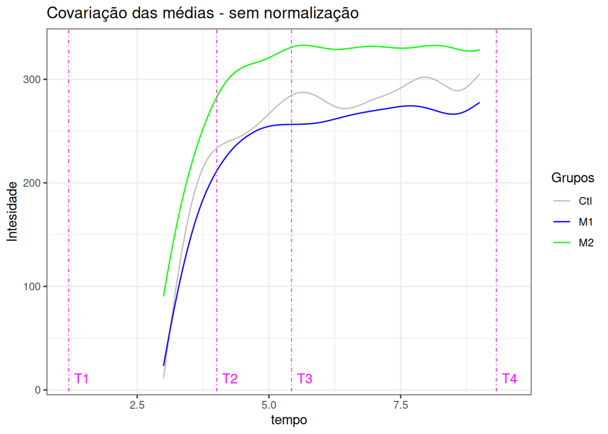

```r
# Prepara os dados para o teste de covariância
#garante o comprimento igual nos 3 datasets
tMax = 9
tMin = 3

dCtl<-ctl$fzM[ctl$tempo >=tMin & ctl$tempo<tMax]
dM1<-itv1$fzM[itv1$tempo >=tMin & itv1$tempo<tMax]
dM2<-itv2$fzM[itv2$tempo >=tMin & itv2$tempo<tMax]
t<-ctl$tempo[ctl$tempo >=tMin & ctl$tempo<tMax]

minY<-min(dCtl,dM1,dM2)

data<- data.frame(tempo = t, int = dCtl, label = 'Ctl' )
tmp <- data.frame(tempo = t, int = dM1, label = 'M1' )
data <- rbind(data,tmp)
tmp <- data.frame(tempo = t, int = dM2, label = 'M2' )
data <- rbind(data,tmp)

ggplot(data = data)+
  ylab("Intesidade")+
  ggtitle('Covariação das médias - sem normalização')+
  geom_line(aes(x = tempo, y = int, colour = as.factor(label)))+
  # geom_line(aes(t,d2),color='blue')+
  # geom_line(aes(t,d3),color='green')+
  geom_vline(xintercept = T1, color='magenta', linetype = "dotdash", size= 0.3)+
  geom_vline(xintercept = T2, color='magenta', linetype = "dotdash", size= 0.3)+
  geom_vline(xintercept = T3, color='magenta', linetype = "dotdash", size= 0.3)+
  geom_vline(xintercept = T4, color='magenta', linetype = "dotdash", size= 0.3)+
  annotate('text',label = c('T1','T2','T3','T4'),
           x=c(T1+0.25,T2+0.25,T3+0.25,T4+0.25),
           y=c(rep(minY,4)),
           color='magenta')+
  scale_color_manual(values = c("Ctl" = "gray", "M1" = "blue", 'M2'= 'green'))+
  guides(color=guide_legend(title="Grupos"))
```

Observando o gráfico das linhas de média não normalizado, notamos que há fortes indícios de que a correlação entre os valores de controle, M1 e M2 são fortes.

```r
#Covariancia entre Controle e M1
cor.test(dCtl,dM1,
         method = "spearman",
         continuity = FALSE,
         conf.level = 0.98)
```

```
    Spearman's rank correlation rho

data:  dCtl and dM1
S = 3660159086, p-value < 2.2e-16
alternative hypothesis: true rho is not equal to 0
sample estimates:
      rho
0.8983289
```

```r
#Covariancia entre Controle e M2
cor.test(dCtl,dM2,
         method = "spearman",
         continuity = FALSE,
         conf.level = 0.98)
```

```
    Spearman's rank correlation rho

data:  dCtl and dM2
S = 7232903412, p-value < 2.2e-16
alternative hypothesis: true rho is not equal to 0
sample estimates:
     rho
0.799086
```

```r
#Covariancia entre M1 e M2
cor.test(dM1,dM2,
         method = "spearman",
         continuity = FALSE,
         conf.level = 0.98)
```

```
    Spearman's rank correlation rho

data:  dM1 and dM2
S = 9536867598, p-value < 2.2e-16
alternative hypothesis: true rho is not equal to 0
sample estimates:
     rho
0.735087
```

Todos os testes indicaram um ρ > 0.73, confirmando assim a correlação entre os resultados obtidos pelo grupo de controle, M1 e M2.

Desta forma, podemos afirmar que também **não há diferença significativa** nos resultados observados para controle, intervenção em M1 e intervenção em M2, segundo o teste Spearman.

# Análise das diferentes fases do Levantar+Bimanual

Para a análise das diferentes fases do levantar+Bimanual, foram utilizados os seguintes parâmetros : ÁreaCoP, Velocidade ântero-posterior, Velocidade médio-lateral, Amplitude de deslocamento do CoP ântero-posterior e Amplitude de deslocamento do CoP médio lateral (ML).

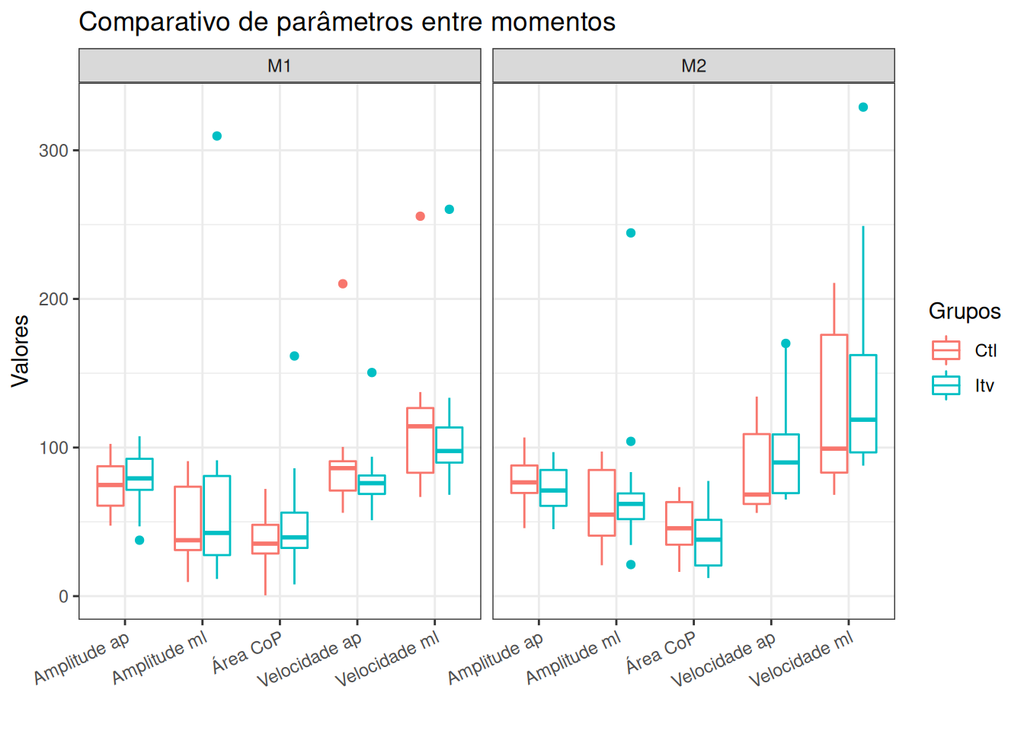

```r
#preparação dos dados

tmp <- get_metrics(picos, ctlM1, ctlM2, itvM1, itvM2)
metricAll <- tmp[[1]]
metricFase <- tmp[[2]]

#titulos para os subgráficos
moment <- c('M1','M2')
names(moment) <- c(1,2)

fases <- c('T1 a T2','T2 a T3', 'T3 a T4')
names(fases) <- c(1,2,3)


ggplot(metricAll)+
  ggtitle('Comparativo de parâmetros entre momentos')+
  geom_boxplot(aes(x = trat, y = valor, col = group)
               # ,trim = F,draw_quantiles = c(0.25,0.5,0.75)
               )+
  labs(x = "", y = "Valores", col = "") +
  scale_x_discrete(limits = c("ampl_ap", "ampl_ml", "area_var", "vel_ap", "vel_ml"),
                   labels = c("Amplitude ap", "Amplitude ml", "Área CoP", "Velocidade ap", "Velocidade ml")) +
  theme(legend.position = "right",
        axis.text.x = element_text(angle = 25, hjust=1))+
  facet_wrap(~moment, labeller = labeller(moment = moment))+
  scale_color_discrete(name = 'Grupos',
                       labels = c('Ctl','Itv'))
```

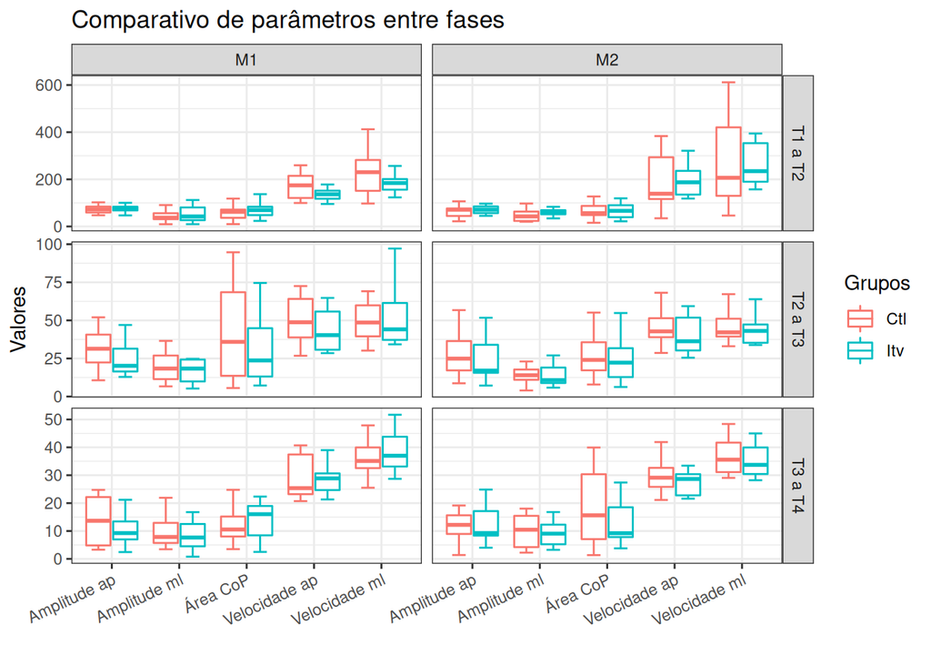

```r
ggplot(metricFase,aes(x = trat, y = valor, col = group))+
  #geom_boxplot()+
  ggtitle('Comparativo de parâmetros entre fases')+
  geom_boxplot2(width = 0.8, width.errorbar = 0.2)+
  labs(x = "", y = "Valores", col = "") +
  scale_x_discrete(limits = c("ampl_ap", "ampl_ml", "area_var", "vel_ap", "vel_ml"),
                   labels = c("Amplitude ap", "Amplitude ml", "Área CoP", "Velocidade ap", "Velocidade ml")) +
  theme(legend.position = "right",
        axis.text.x = element_text(angle = 25, hjust=1))+
  facet_grid(fase~moment,
             labeller = labeller(
                            moment = moment,
                            fase = fases),
                            scales = "free")+
  scale_color_discrete(name = 'Grupos',
                       labels = c('Ctl','Itv'))
```

## Testes Estatísticos

Foram comparadas as distribuições de resultados obtidas entre os grupos intervenção e controle tanto globalmente, quanto fase a fase para todos os parâmetros mencionados.

Foram realizados os testes **Two-sample t-test** e o **Welch Two Sample t-test**, comparando-se sempre as distribuições do grupo intervenção e respectivo controle nos momentos M1 e M2.

Ambos os testes tem como hipótese nula que a média distribuição das duas categorias são iguais. A diferença entre eles é que o primeiro considera que as distribuições comparadas tem variâncias semelhantes e o segundo não.

Conforme pode ser visto nos resultados dos testes, listados abaixo, **não houve diferença significantiva entre nenhuma das situações comparadas**. Assim, conclui-se que os grupos **intervenção e o controle** são similares considerados todos os parâmetros.

### Parâmetros analisados globalmente

#### Two-sample t-test

```r
#Realizando o Two-sample t-test para cada sub-grupo
param = unique(metricAll$trat)
for(momento in 1:2) {
  for(trat in param){
    tmp <- metricAll[metricAll$moment == momento &
                       metricAll$trat == trat,
                     c('group','valor')]
    cat('##################################\n\n',paste0('M',momento),' Parâmetro:', trat,'\n')
    print(t.test(valor ~ group, data=tmp,
           var.equal=T,
           conf.level=0.95))
  }
}
```

```
##################################

 M1  Parâmetro: ampl_ml

    Two Sample t-test

data:  valor by group
t = -0.71367, df = 24, p-value = 0.4823
alternative hypothesis: true difference in means between group c and group i is not equal to 0
95 percent confidence interval:
 -63.62076  30.92719
sample estimates:
mean in group c mean in group i
       49.61445        65.96124

##################################

 M1  Parâmetro: ampl_ap

    Two Sample t-test

data:  valor by group
t = -0.52209, df = 24, p-value = 0.6064
alternative hypothesis: true difference in means between group c and group i is not equal to 0
95 percent confidence interval:
 -18.84890  11.23804
sample estimates:
mean in group c mean in group i
       74.94304        78.74847

##################################

 M1  Parâmetro: area_var

    Two Sample t-test

data:  valor by group
t = -1.1475, df = 24, p-value = 0.2625
alternative hypothesis: true difference in means between group c and group i is not equal to 0
95 percent confidence interval:
```

[output cut: 94 more lines]

```

##################################

 M2  Parâmetro: vel_ap

    Two Sample t-test

data:  valor by group
t = -0.99305, df = 24, p-value = 0.3306
alternative hypothesis: true difference in means between group c and group i is not equal to 0
95 percent confidence interval:
 -39.65707  13.89181
sample estimates:
mean in group c mean in group i
       85.71705        98.59968
```

#### Welch Two Sample t-test

```r
#Realizando o Two-sample t-test para cada sub-grupo
param = unique(metricAll$trat)
for(momento in 1:2) {
  for(trat in param){
    tmp <- metricAll[metricAll$moment == momento &
                       metricAll$trat == trat,
                     c('group','valor')]
    cat('##################################\n\n',paste0('M',momento),' Parâmetro:', trat,'\n')
    print(t.test(valor ~ group, data=tmp,
           var.equal=F,
           conf.level=0.95))
  }
}
```

```
##################################

 M1  Parâmetro: ampl_ml

    Welch Two Sample t-test

data:  valor by group
t = -0.75815, df = 17.039, p-value = 0.4587
alternative hypothesis: true difference in means between group c and group i is not equal to 0
95 percent confidence interval:
 -61.82972  29.13616
sample estimates:
mean in group c mean in group i
       49.61445        65.96124

##################################

 M1  Parâmetro: ampl_ap

    Welch Two Sample t-test

data:  valor by group
t = -0.52669, df = 23.938, p-value = 0.6033
alternative hypothesis: true difference in means between group c and group i is not equal to 0
95 percent confidence interval:
 -18.71965  11.10879
sample estimates:
mean in group c mean in group i
       74.94304        78.74847

##################################

 M1  Parâmetro: area_var

    Welch Two Sample t-test

data:  valor by group
t = -1.1957, df = 21.068, p-value = 0.2451
alternative hypothesis: true difference in means between group c and group i is not equal to 0
95 percent confidence interval:
```

[output cut: 94 more lines]

[output not shown]

### Parâmetros analisados por fase do levantar+Bimanual

#### Two-sample t-test

```r
for(momento in 1:2) {
  for(trat in param){
    for( fase in 1:3){
      tmp <- metricFase[metricFase$moment == momento &
                       metricFase$trat == trat &
                         metricFase$fase == fase,
                     c('group','valor')]
      cat('##################################\n\n',
          paste0('M',momento),' Parâmetro:', trat,
          'Fase:', fase,'\n')
      print(t.test(valor ~ group, data=tmp,
           var.equal=T,
           conf.level=0.95))
    }
  }
}
```

```
##################################

 M1  Parâmetro: ampl_ml Fase: 1

    Two Sample t-test

data:  valor by group
t = -0.51745, df = 24, p-value = 0.6096
alternative hypothesis: true difference in means between group c and group i is not equal to 0
95 percent confidence interval:
 -29.67694  17.77910
sample estimates:
mean in group c mean in group i
       45.21145        51.16037

##################################

 M1  Parâmetro: ampl_ml Fase: 2

    Two Sample t-test

data:  valor by group
t = -0.54595, df = 24, p-value = 0.5901
alternative hypothesis: true difference in means between group c and group i is not equal to 0
95 percent confidence interval:
 -23.57377  13.71106
sample estimates:
mean in group c mean in group i
       22.15896        27.09031

##################################

 M1  Parâmetro: ampl_ml Fase: 3

    Two Sample t-test

data:  valor by group
t = -0.72783, df = 24, p-value = 0.4738
alternative hypothesis: true difference in means between group c and group i is not equal to 0
95 percent confidence interval:
```

[output cut: 394 more lines]

```

##################################

 M2  Parâmetro: vel_ap Fase: 3

    Two Sample t-test

data:  valor by group
t = 0.76605, df = 24, p-value = 0.4511
alternative hypothesis: true difference in means between group c and group i is not equal to 0
95 percent confidence interval:
 -3.087282  6.731800
sample estimates:
mean in group c mean in group i
       29.87184        28.04958
```

#### Welch Two Sample t-test

```r
for(momento in 1:2) {
  for(trat in param){
    for( fase in 1:3){
      tmp <- metricFase[metricFase$moment == momento &
                       metricFase$trat == trat &
                         metricFase$fase == fase,
                     c('group','valor')]
      cat('##################################\n\n',
          paste0('M',momento),' Parâmetro:', trat,
          'Fase:', fase,'\n')
      print(t.test(valor ~ group, data=tmp,
           var.equal=F,
           conf.level=0.95))
    }
  }
}
```

```
##################################

 M1  Parâmetro: ampl_ml Fase: 1

    Welch Two Sample t-test

data:  valor by group
t = -0.52676, df = 23.898, p-value = 0.6032
alternative hypothesis: true difference in means between group c and group i is not equal to 0
95 percent confidence interval:
 -29.26258  17.36474
sample estimates:
mean in group c mean in group i
       45.21145        51.16037

##################################

 M1  Parâmetro: ampl_ml Fase: 2

    Welch Two Sample t-test

data:  valor by group
t = -0.57236, df = 19.869, p-value = 0.5735
alternative hypothesis: true difference in means between group c and group i is not equal to 0
95 percent confidence interval:
 -22.91129  13.04858
sample estimates:
mean in group c mean in group i
       22.15896        27.09031

##################################

 M1  Parâmetro: ampl_ml Fase: 3

    Welch Two Sample t-test

data:  valor by group
t = -0.77971, df = 15.238, p-value = 0.4475
alternative hypothesis: true difference in means between group c and group i is not equal to 0
95 percent confidence interval:
```

[output cut: 394 more lines]

```

##################################

 M2  Parâmetro: vel_ap Fase: 3

    Welch Two Sample t-test

data:  valor by group
t = 0.76395, df = 23.121, p-value = 0.4526
alternative hypothesis: true difference in means between group c and group i is not equal to 0
95 percent confidence interval:
 -3.110715  6.755233
sample estimates:
mean in group c mean in group i
       29.87184        28.04958
```